# Network analysis of Star Wars: The Attack of the Clones (episode 2) in R

This is a free adaptation of two (very) clever analyses made by others:

- [The Star Wars Social Network by Evelina Gabasov](http://evelinag.com/blog/2015/12-15-star-wars-social-network) in which program F# was mostly used to analyse the Star wars social networks
- [Analyzing networks of characters in ‘Love Actually’ by David Robinson](http://varianceexplained.org/r/love-actually-network/) in which R was used to analyse the links between the characters of the movie Love Actually.

The aim here is to try and reproduce Evelina’s analysis using R only, using David’s contribution plus several tweaks I found here and there on the internet.

# Read and format data

First, read in data. I found the movie script in doc format here, which I converted in txt format for convenience. Then, apply various treatment to have the data ready for analysis.

```r
# load convenient packages
library(dplyr)
library(stringr)
library(tidyr)

# read file line by line
raw <- readLines("attack-of-the-clones.txt")

# create data frame
lines <- data_frame(raw = raw)

# get rid of leading and trailing white spaces
# http://stackoverflow.com/questions/2261079/how-to-trim-leading-and-trailing-whitespace-in-r
trim <- function (x) gsub("^\\s+|\\s+$", "", x)
lines= mutate(lines,raw=trim(raw))

# get rid of the empty lines
lines2 <- filter(lines, raw != "")

# detect scenes: begin by EXT. or INT.
lines3 <-  mutate(lines2, is_scene = str_detect(raw, "T."),scene = cumsum(is_scene))

# drop lines that start with EXT. or INT.
lines4 <- filter(lines3,!is_scene)

# distinguish characters from what they say
lines5 <- separate(lines4, raw, c("speaker", "dialogue"), sep = ":", fill = "left",extra='drop')

# read in aliases (from Evelina's post)
aliases <- read.table('aliases.csv',sep=',',header=T,colClasses = "character")
aliases$Alias
```

```
##  [1] "BEN"           "SEE-THREEPIO"  "THREEPIO"      "ARTOO-DETOO"
##  [5] "ARTOO"         "PALPATINE"     "DARTH SIDIOUS" "BAIL"
##  [9] "MACE"          "WINDU"         "MACE-WINDU"    "NUTE"
## [13] "AUNT BERU"     "DOOKU"         "BOBA"          "JANGO"
## [17] "PANAKA"        "NUTE"          "KI-ADI"        "BIBBLE"
## [21] "BIB"           "CHEWIE"        "VADER"
```

```r
aliases$Name
```

```
##  [1] "OBI-WAN"        "C-3PO"          "C-3PO"          "R2-D2"
##  [5] "R2-D2"          "EMPEROR"        "EMPEROR"        "BAIL ORGANA"
##  [9] "MACE WINDU"     "MACE WINDU"     "MACE WINDU"     "NUTE GUNRAY"
## [13] "BERU"           "COUNT DOOKU"    "BOBA FETT"      "JANGO FETT"
## [17] "CAPTAIN PANAKA" "NUTE GUNRAY"    "KI-ADI-MUNDI"   "SIO BIBBLE"
## [21] "BIB FORTUNA"    "CHEWBACCA"      "DARTH VADER"
```

```r
# assign unique name to characters
# http://stackoverflow.com/questions/28593265/is-there-a-function-like-switch-which-works-inside-of-dplyrmutate
multipleReplace <- function(x, what, by) {
  stopifnot(length(what)==length(by))
  ind <- match(x, what)
  ifelse(is.na(ind),x,by[ind])
}
lines6 <- mutate(lines5,speaker=multipleReplace(speaker,what=aliases$Alias,by=aliases$Name))

# read in actual names (from Evelina's post)
actual.names <- read.csv('characters.csv',header=F,colClasses = "character")
actual.names <- c(as.matrix(actual.names))
# filter out non-characters
lines7 <- filter(lines6,speaker %in% actual.names)

# group by scene
lines8 <- group_by(lines7, scene, line = cumsum(!is.na(speaker)))

lines9 <- summarize(lines8, speaker = speaker[1], dialogue = str_c(dialogue, collapse = " "))

# Count the lines-per-scene-per-character
# Turn the result into a binary speaker-by-scene matrix
by_speaker_scene <- count(lines9, scene, speaker)
by_speaker_scene
```

```
## Source: local data frame [447 x 3]
## Groups: scene [?]
##
##    scene    speaker     n
##    (int)      (chr) (int)
## 1     26      PADME     1
## 2     27      PADME     1
## 3     29      PADME     1
## 4     48      PADME     1
## 5     50      PADME     2
## 6     66 MACE WINDU     1
## 7     67 MACE WINDU     1
## 8     69       YODA     1
## 9     70 MACE WINDU     1
## 10    74       YODA     1
## ..   ...        ...   ...
```

```r
library(reshape2)
speaker_scene_matrix <-acast(by_speaker_scene , speaker ~ scene, fun.aggregate = length)
dim(speaker_scene_matrix)
```

```
## [1]  19 321
```

# Analyses

## Hierarchical clustering

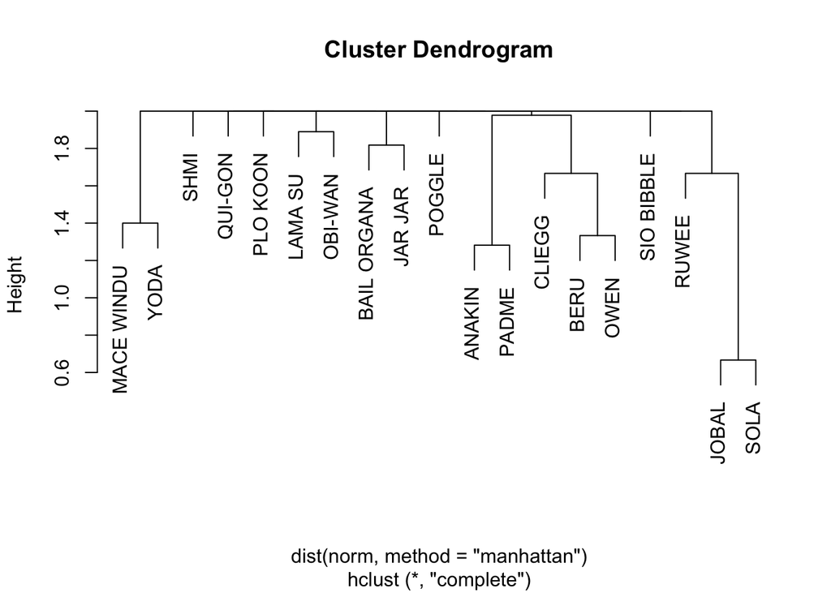

```r
norm <- speaker_scene_matrix / rowSums(speaker_scene_matrix)
h <- hclust(dist(norm, method = "manhattan"))
plot(h)
```

## Timeline

Use tree to give an ordering that puts similar characters close together

```r
ordering <- h$labels[h$order]
ordering
```

```
##  [1] "MACE WINDU"  "YODA"        "SHMI"        "QUI-GON"     "PLO KOON"
##  [6] "LAMA SU"     "OBI-WAN"     "BAIL ORGANA" "JAR JAR"     "POGGLE"
## [11] "ANAKIN"      "PADME"       "CLIEGG"      "BERU"        "OWEN"
## [16] "SIO BIBBLE"  "RUWEE"       "JOBAL"       "SOLA"
```

This ordering can be used to make other graphs more informative. For instance, we can visualize a timeline of all scenes:

[figure not shown]

```r
scenes <-  filter(by_speaker_scene, n() > 1) # scenes with > 1 character
scenes2 <- ungroup(scenes)
scenes3 <- mutate(scenes2, scene = as.numeric(factor(scene)),
           character = factor(speaker, levels = ordering))
library(ggplot2)
ggplot(scenes3, aes(scene, character)) +
    geom_point() +
    geom_path(aes(group = scene))
```

Create a cooccurence matrix (see [here](http://stackoverflow.com/questions/13281303/creating-co-occurrence-matrix)) containing how many times two characters share scenes

[figure not shown]

```r
cooccur <- speaker_scene_matrix %*% t(speaker_scene_matrix)
heatmap(cooccur)
```

## Social network analyses

### Graphical representation of the network

Here the nodes represent characters in the movies. The characters are connected by a link if they both speak in the same scene. And the more the characters speak together, the thicker the link between them.

[figure not shown]

```r
library(igraph)
g <- graph.adjacency(cooccur, weighted = TRUE, mode = "undirected", diag = FALSE)
plot(g, edge.width = E(g)$weight)
```

Compute standard network features, degree and betweeness

```r
degree(g)
```

```
##      ANAKIN BAIL ORGANA        BERU      CLIEGG     JAR JAR       JOBAL
##          12           1           4           4           4           4
##     LAMA SU  MACE WINDU     OBI-WAN        OWEN       PADME    PLO KOON
##           1           5           6           4          12           0
##      POGGLE     QUI-GON       RUWEE        SHMI  SIO BIBBLE        SOLA
##           1           1           4           1           0           4
##        YODA
##           4
```

```r
betweenness(g)
```

```
##      ANAKIN BAIL ORGANA        BERU      CLIEGG     JAR JAR       JOBAL
##   42.600000    0.000000    1.750000    0.500000   22.000000    0.000000
##     LAMA SU  MACE WINDU     OBI-WAN        OWEN       PADME    PLO KOON
##    0.000000   18.366667   15.000000    5.250000   55.133333    0.000000
##      POGGLE     QUI-GON       RUWEE        SHMI  SIO BIBBLE        SOLA
##    0.000000    0.000000    0.700000    0.000000    0.000000    5.000000
##        YODA
##    3.366667
```

Get a nicer representation of the network. See [here](http://tagteam.harvard.edu/hub_feeds/1981/feed_items/1388531), for formating from igraph to d3Network.

```r
library(d3Network)
library(networkD3)
sg <- simplify(g)
df <- get.edgelist(g, names=TRUE)
df <- as.data.frame(df)
colnames(df) <- c('source', 'target')
df$value <- rep(1, nrow(df))
# get communities
fc <- fastgreedy.community(g)
com <- membership(fc)
node.info <- data.frame(name=names(com), group=as.vector(com))
links <- data.frame(source=match(df$source, node.info$name)-1,target=match(df$target, node.info$name)-1,value=df$value)

forceNetwork(Links = links, Nodes = node.info,Source = "source", Target = "target",Value = "value", NodeID = "name",Group = "group", opacity = 1, opacityNoHover=1)
```

[interactive chart not shown]

Here the nodes represent characters in the movies. The characters are connected by a link if they both speak in the same scene. The colors are for groups obtained by some algorithms